# Final

Kiara Dorion

# Dependencies

```r
library(dplyr) # for data manipulation, but really just for dplyr::bind_rows()
library(ggplot2) # for plotting your simulation results
library(grf) # for regression forests
library(patchwork) # use this to combine ggplots; see the demo in Canvas
```

# 1 Question 1

```r
set.seed(42)

#simulate confounders
n = 1e3
HC = rnorm(n,0,1) #this represents health consciousness
PA = rnorm(n,0,1) #this represents physical activity

#treatment assignment: WHOOP usage depends on HC and PA
propensity_score = plogis(1.2 * HC + 0.8 * PA)
Treat = rbinom(n,1,propensity_score)

#simulate sleep quality score (outcome)
tau_true = 2 #true effect of WHOOP on sleep quality
noise = rnorm(n,0,1)
Y = 70 + tau_true * Treat + 1.5 * HC + 1.0 * PA + noise

df = data.frame(HC,PA,Treat,Y)

#Run causal forest to adjust for confounders
X =  df[, c("HC", "PA")]
W = df$Treat
Y_obs = df$Y

cf = causal_forest(X,Y_obs,W)
tau = average_treatment_effect(cf,target.sample = "control") #controlling for lack of overlap

#print(paste("Estimated ATE:", round(tau,2)))
#checking spread of propensity scores check if theres good overlop
#(propensity_score, breaks = 30, main = "Distribution of Propensity Scores", xlab = "P(T = 1 | HC, PA)")
```

Interpretation: Simulated observational study to estimate the causal effect of WHOOP device usage on sleep quality, accounting for confounding variables.

Variables: Treatment (Treat): WHOOP device usage (1 = user, 0 = non-user) Outcome (Y): Sleep quality score (e.g., based on duration, efficiency, and disturbances) Confounders: Health Consciousness (HC): Individuals who are more aware of health may be more likely to use WHOOP and have better sleep. Physical Activity Level (PA): More active Individuals may be more inclined to use WHOOP and also experience better sleep.

# 2 Question 2.1

```r
simulate_experiment = function(n=1e5, tau=3, linear=TRUE) {
  #Convert n to integer if it's passed as 1e5
  n = as.integer(n)

  #Simulate X1,X2,X3 ~ N(0,1)
  X1 = rnorm(n)
  X2 = rnorm(n)
  X3 = rnorm(n)

  #simulate epsilon
  epsilon = rnorm(n)

  #Treatment assignment probability P(W=1|X)
   if (linear) {
    ps = 1 / (1 + exp(-X3))  #Log function of X3
  } else {
    ps = 1 / (1 + exp(- (1 + sin(X1) + cos(X2)^2)))  #More complex
  }

  #simulate treatment W ~ Bernoulli(ps)
  W = rbinom(n,1,ps)

 # Generate outcome Y
  if (linear) {
    Y = tau * W + X1 + X2 + X3 + epsilon
  } else {
    Y = tau * W + X1^3 + 3 * sin(X2) + pmax(X3, 0) + X1 * X2 + epsilon
  }

  # Return as data.frame
  return(data.frame(
    Y = Y,
    X1 = X1,
    X2 = X2,
    X3 = X3,
    W = W,
    tau = tau,
    linear = linear
  ))
}
#simulate_experiment()
```

# 3 Question 2.2

```r
# Simulate data
sample_data = simulate_experiment(n = 10000, tau = 3, linear = TRUE)

simulate_ate = function(sample_data, method = "ols") {
  Y = sample_data$Y
  W = sample_data$W
  X = as.matrix(sample_data[, c("X1", "X2", "X3")])

  if (method == "ols") {
    model_ols = lm(Y ~ W + X1 + X2 + X3, data = sample_data)
    return(coef(model_ols)["W"])
  }

  if (method == "aipw_manual") {
    propensity_model = glm(W ~ X1 + X2 + X3, data = sample_data, family = binomial)
    e_hat = predict(propensity_model, type = "response")

    mu1_model = lm(Y ~ X1 + X2 + X3, data = sample_data, subset = W == 1)
    mu0_model = lm(Y ~ X1 + X2 + X3, data = sample_data, subset = W == 0)

    mu1_hat = predict(mu1_model, newdata = sample_data)
    mu0_hat = predict(mu0_model, newdata = sample_data)

    D = mu1_hat - mu0_hat
    R = (W * (Y - mu1_hat) / e_hat) - ((1 - W) * (Y - mu0_hat) / (1 - e_hat))

    tau_hat = mean(D + R)
    return(tau_hat)
  }

  if (method == "causal_forest") {
    cf_model = causal_forest(X, Y, W)
    tau_hat = average_treatment_effect(cf_model, target.sample = "control")
    return(as.numeric(tau_hat[["estimate"]]))  # safely extract scalar
  }

  stop("Method must be one of: 'ols', 'aipw_manual', or 'causal_forest'")
}

#print(paste("OLS Simulated ATE:", simulate_ate(sample_data, method = "ols")))
#print(paste("AIPW Manual Simulated ATE:", simulate_ate(sample_data, method = "aipw_manual")))
#print(paste("Causal Forest Simulated ATE (Estimate/Error):", simulate_ate(sample_data, method = "causal_forest")))
```

# 4 Question 2.3

```r
master_data = simulate_experiment(n = 1e5, tau = 3, linear = TRUE)

monte_carlo_ate = function(data,
                            sample_size = c(100, 500, 1000, 2000),
                            n_sims = 1e2,
                            method = "ols") {
  # Ensure n_sims is an integer
  n_sims = as.integer(n_sims)

  # Create a list to store results from each sample size
  results_list = list()

  # Loop over each sample size
  for (s in sample_size) {
    tau_hats = numeric(n_sims)

    for (i in 1:n_sims) {
      # Sample with replacement from the full data
      sample_data = data[sample(1:nrow(data), size = s, replace = TRUE), ]

      # Estimate tau
      tau_hat = simulate_ate(sample_data, method = method)
      tau_hats[i] = tau_hat
    }

    # Store results as a data.frame
    df = data.frame(
      sample_size = rep(s, n_sims),
      tau_hat = tau_hats,
      tau = data$tau[1],
      linear = data$linear[1],
      method = ifelse(method == "ols", "ols", "machine_learning")
    )

    # Append to list
    results_list[[as.character(s)]] = df
  }

  # Combine into a single data.frame
  final_results = dplyr::bind_rows(results_list)
  return(final_results)
}

#Run monte carlo experiment and show results
#results_df = monte_carlo_ate(data = master_data, method = "ols", n_sims = 100)
#head(results_df)
```

# 5 Question 2.4

```r
#Simulate linear and nonlinear data
df_linear = simulate_experiment(n = 1e5, tau = 3, linear = TRUE)
df_nonlinear = simulate_experiment(n = 1e5, tau = 3, linear = FALSE)
```

# 6 Question 2.5

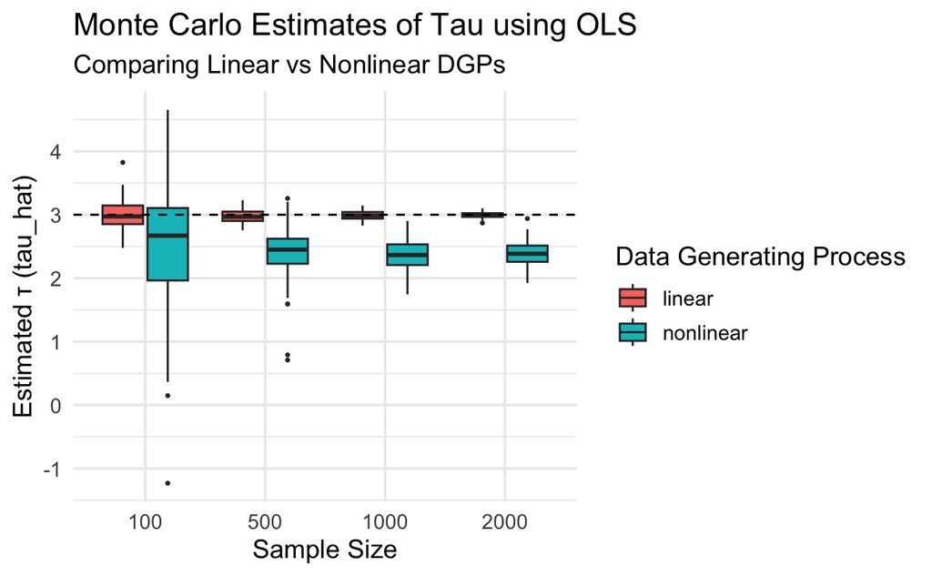

```r
#Run Monte Carlo simulation using OLS on both datasets
results_linear = monte_carlo_ate(data = df_linear, method = "ols")
results_nonlinear = monte_carlo_ate(data = df_nonlinear, method = "ols")

#Add a label to each for plotting
results_linear$label = "linear"
results_nonlinear$label = "nonlinear"

#Combine results
results_combined = dplyr::bind_rows(results_linear, results_nonlinear)

#boxplot
ggplot(results_combined, aes(x = factor(sample_size), y = tau_hat, fill = label)) +
  geom_boxplot(outlier.size = 0.5) +
  geom_hline(yintercept = 3, linetype = "dashed", color = "black") +
  labs(
    title = "Monte Carlo Estimates of Tau using OLS",
    subtitle = "Comparing Linear vs Nonlinear DGPs",
    x = "Sample Size",
    y = "Estimated τ (tau_hat)",
    fill = "Data Generating Process"
  ) +
  theme_minimal(base_size = 13)
```

# 7 Question 2.6

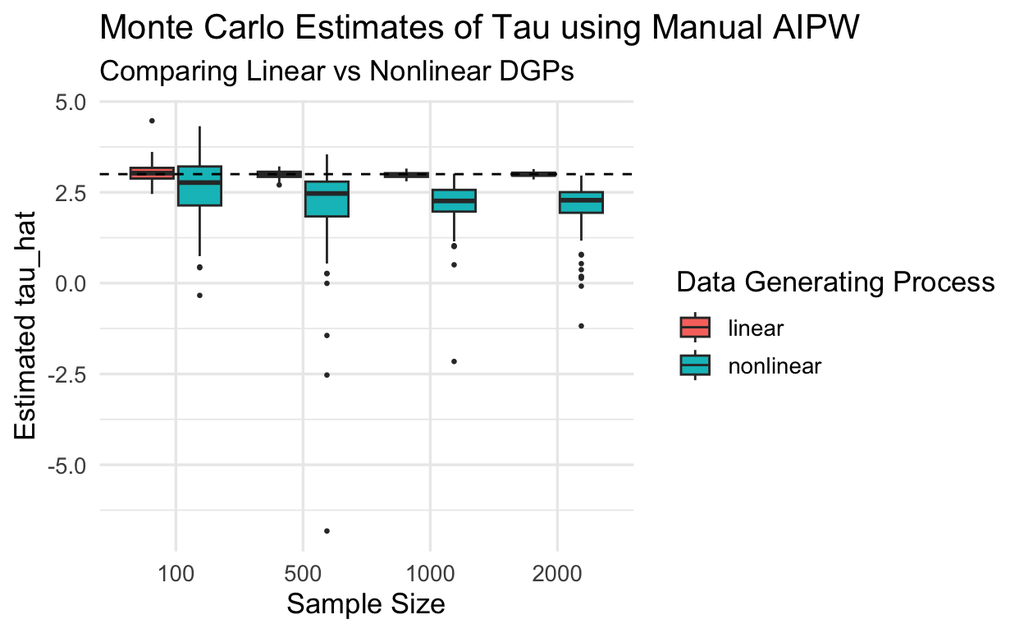

```r
#Run Monte Carlo simulation using manual AIPW
results_linear = monte_carlo_ate(data = df_linear, method = "aipw_manual")
results_nonlinear = monte_carlo_ate(data = df_nonlinear, method = "aipw_manual")

#Label each set
results_linear$label = "linear"
results_nonlinear$label = "nonlinear"

#Combine results
results_combined = dplyr::bind_rows(results_linear, results_nonlinear)

#boxplot
ggplot(results_combined, aes(x = factor(sample_size), y = tau_hat, fill = label)) +
  geom_boxplot(outlier.size = 0.5) +
  geom_hline(yintercept = 3, linetype = "dashed", color = "black") +
  labs(
    title = "Monte Carlo Estimates of Tau using Manual AIPW",
    subtitle = "Comparing Linear vs Nonlinear DGPs",
    x = "Sample Size",
    y = "Estimated tau_hat",
    fill = "Data Generating Process"
  ) +
  theme_minimal(base_size = 13)
```

# 8 Question 2.7

```r
#Run Monte Carlo with causal forest
results_linear = monte_carlo_ate(data = df_linear, method = "causal_forest")
results_nonlinear = monte_carlo_ate(data = df_nonlinear, method = "causal_forest")

#Label each result set
results_linear$label = "linear"
results_nonlinear$label = "nonlinear"

#Combine both
results_combined = dplyr::bind_rows(results_linear, results_nonlinear)

#boxplot of monte carlo estimates using causal forest
ggplot(results_combined, aes(x = factor(sample_size), y = tau_hat, fill = label)) +
  geom_boxplot(outlier.size = 0.5) +
  geom_hline(yintercept = 3, linetype = "dashed", color = "black") +
  labs(
    title = "Monte Carlo Estimates of Tau using Causal Forest",
    subtitle = "Comparing Linear vs Nonlinear DGPs",
    x = "Sample Size",
    y = "Estimated tau_hat",
    fill = "Data Generating Process"
  ) +
  theme_minimal(base_size = 13)
```

[output not shown]

# 9 Question 2.8

```r
## Method Comparison – Parametric vs. Non-Parametric Estimators
# This simulation demonstrates how estimator performance depends on both data structure and modeling assumptions. Choosing the right method means balancing interpretability, robustness, and real-world complexity.
```

## 9.1 Method Comparison – Parametric vs. Non-Parametric Estimators

### 9.1.1 Key Takeaways from the Simulation

Goal: This simulation helped us explore how different types of models estimate the true impact of a treatment. We focused on whether each method could consistently get close to the actual average treatment effect (ATE), especially when the data relationships were either simple (linear) or more complex (nonlinear).

### 9.1.2 Strengths of Parametric Methods (OLS, AIPW)

- OLS (Ordinary Least Squares) is fast and easy to use. It works well when the relationship between variables is truly linear.
- AIPW (Augmented Inverse Probability Weighting) is more flexible. It still gives reliable results even if only one part of the model (the outcome or the treatment prediction) is correct.

### 9.1.3 Weaknesses of Parametric Methods

- OLS can give the wrong answer if the relationship in the data is nonlinear or includes complex interactions.
- AIPW still assumes that one of the two models (either for treatment or outcome) is specified correctly — which may not always be true.

### 9.1.4 Strengths of Non-Parametric Method (Causal Forest)

- Causal Forest doesn’t assume a specific shape or structure for the data — it learns directly from patterns in the data.
- It’s great at picking up complex trends and interactions between variables.
- It still produces consistent estimates of treatment effects, even when simpler models like OLS fail.

### 9.1.5 Weaknesses of Non-Parametric Method

- It needs more data to perform well. With small samples, it can be unstable or noisy.
- It’s harder to explain or interpret compared to something like OLS.
- It also takes longer to run, especially in simulations.

### 9.1.6 Final Takeaway

- Use OLS when we’re confident the relationships in your data are simple and linear.
- Use AIPW when we want some protection in case your model isn’t perfect.
- Use Causal Forest when you expect more complicated patterns or we’re working with messy, real-world data — as long as we have enough observations.